# Final project

## Introduction: Breast cancer

[EU Science Hub](https://ec.europa.eu/jrc/en/news/2020-cancer-incidence-and-mortality-eu-27-countries)

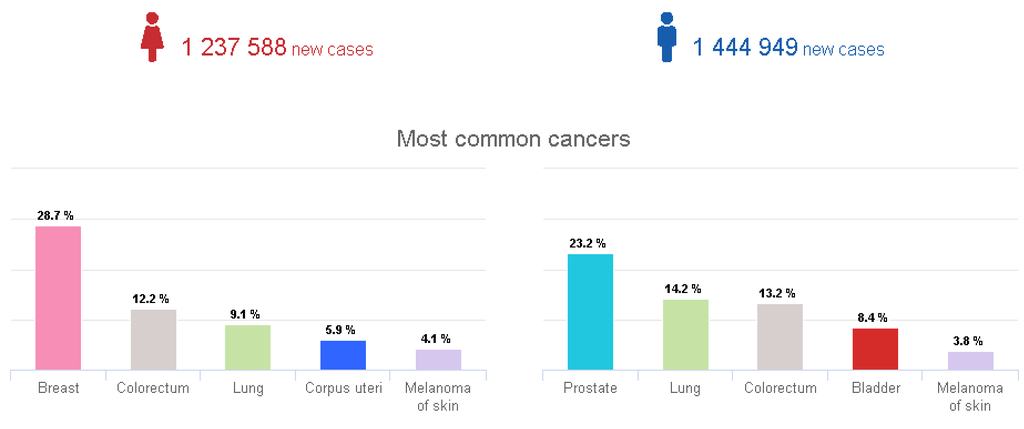

## Materials and methods

## Materials

[Kaggle breast cancer data](https://www.kaggle.com/homayoonkhadivi/breast-cancer-datasets)

26 explanatory variables.

- Condition
- Tumor type

| patient_id | gender | education | treatment_data | id_healthcenter | id_treatment_region | hereditary_history | birth_date | age | weight | thickness_tumor | marital_status | marital_length | pregnency_experience | giving_birth | age_FirstGivingBirth | abortion | blood | taking_heartMedicine | taking_blood_pressure_medicine | taking_gallbladder_disease_medicine | smoking | alcohol | breast_pain | radiation_history | Birth_control(Contraception) | menstrual_age | menopausal_age | Benign_malignant_cancer | condition |
| --- | --- | --- | --- | --- | --- | --- | --- | --- | --- | --- | --- | --- | --- | --- | --- | --- | --- | --- | --- | --- | --- | --- | --- | --- | --- | --- | --- | --- | --- |
| 111036008041 | 0 | 4 | 2019 | 1.11e+09 | 1.11e+09 | 1 | 1989 | 30 | 69 | 0.90 | 1 | 0 | 0 | 0 | 0 | 0 | 4 | 0 | 1 | 1 | 0 | 0 | 1 | 1 | 1 | 1 | 0 | 1 | death |
| 111035996130 | 0 | 6 | 2019 | 1.11e+09 | 1.11e+09 | 0 | 1989 | 30 | 71 | 0.80 | 0 | 0 | 0 | 0 | 0 | 0 | 1 | 1 | 1 | 1 | 0 | 1 | 0 | 0 | 0 | 2 | 0 | 0 | death |
| 111035971333 | 0 | 5 | 2019 | 1.11e+09 | 1.11e+09 | 0 | 1989 | 30 | 74 | 0.90 | 1 | 0 | 0 | 0 | 0 | 1 | 4 | 1 | 1 | 0 | 0 | 0 | 1 | 1 | 0 | 1 | 0 | 1 | death |
| 111036018485 | 0 | 5 | 2019 | 1.11e+09 | 1.11e+09 | 1 | 1989 | 30 | 75 | 0.70 | 1 | 1 | 1 | 3 | 1 | 0 | 2 | 1 | 1 | 1 | 1 | 0 | 0 | 0 | 0 | 2 | 0 | 0 | death |
| 111035985474 | 0 | 1 | 2019 | 1.11e+09 | 1.11e+09 | 0 | 2009 | 10 | 70 | 0.25 | 0 | 0 | 0 | 0 | 0 | 0 | 7 | 0 | 0 | 0 | 0 | 0 | 0 | 0 | 0 | 0 | 0 | 0 | death |
| 111035903616 | 0 | 3 | 2019 | 1.11e+09 | 1.11e+09 | 1 | 1989 | 30 | 79 | 0.70 | 0 | 0 | 0 | 0 | 0 | 0 | 6 | 1 | 1 | 1 | 0 | 1 | 1 | 1 | 1 | 1 | 0 | 1 | death |
| 111036003507 | 0 | 4 | 2019 | 1.11e+09 | 1.11e+09 | 1 | 1990 | 29 | 96 | 0.10 | 0 | 0 | 0 | 0 | 0 | 0 | 4 | 1 | 1 | 0 | 0 | 0 | 1 | 1 | 0 | 2 | 0 | 1 | death |
| 111036026259 | 0 | 5 | 2019 | 1.11e+09 | 1.11e+09 | 0 | 1990 | 29 | 75 | 0.80 | 0 | 0 | 0 | 0 | 0 | 0 | 0 | 0 | 1 | 1 | 0 | 1 | 0 | 0 | 0 | 2 | 0 | 0 | death |

## Process

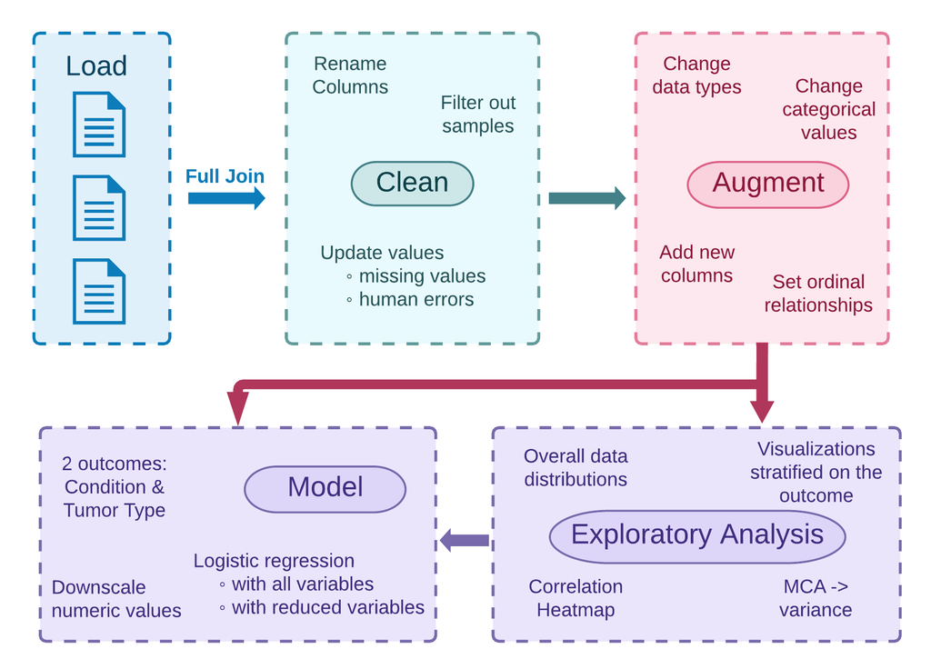

## Cleaning the data

Unrealistic age and weight proportions.

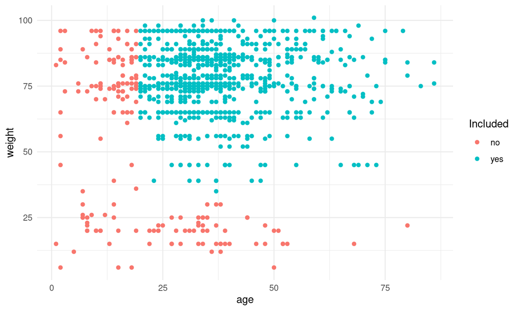

## Cleaning the data

| **Column names** |
| --- |
| Removed special characters from variable names |
| **Variable values** |
| Greedy cleanup of binary variables |
| Blood type had non-conforming entries which were set to NA |
| Birth dates of other than 4 numbers were set to NA |
| **Filter out samples** |
| Only include women > 20 years, as they are the primary risk group |
| Remove abnormal attribute combinations |
| **Removing columns** |
| Remove singular columns (with only one value for all samples) |

## Augmenting the data

| **Values changed** |
| --- |
| Categorical variables as factor |
| Explicit values for categorical variables |
| **Adding columns** |
| Age at treatment |
| Normalised numerical variables |

## Exploratory Analysis

## Distributions

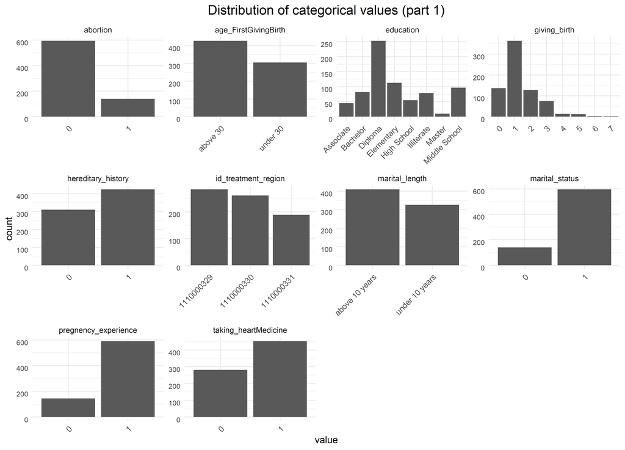

## Distributions

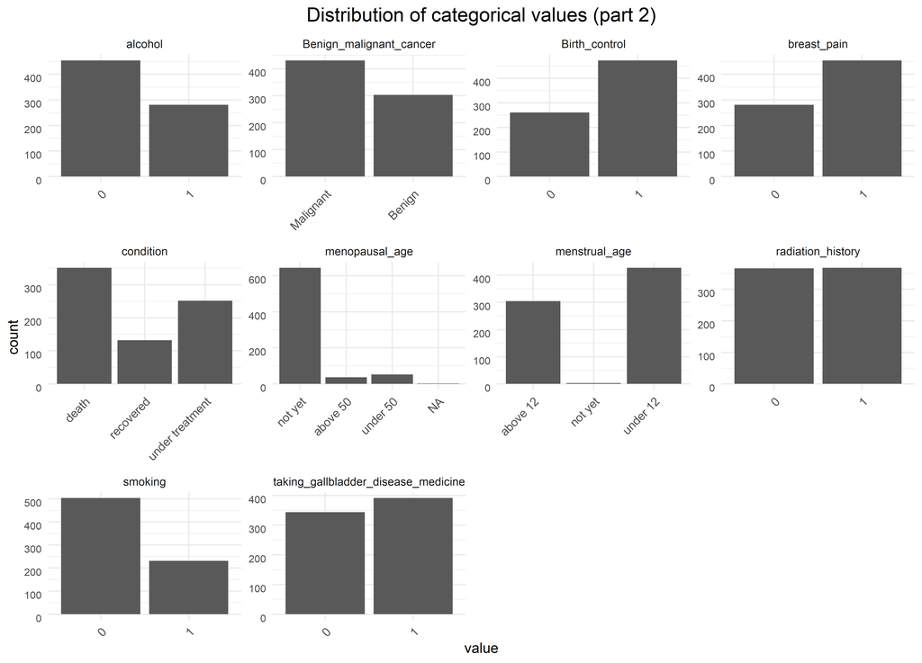

## Distributions

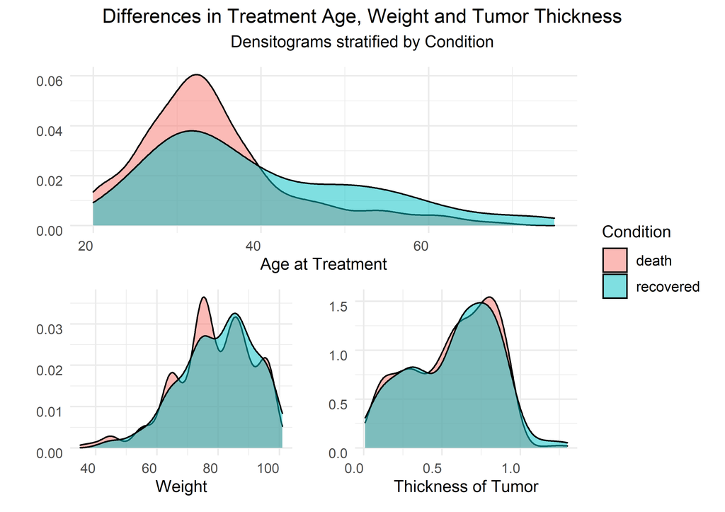

## Distributions

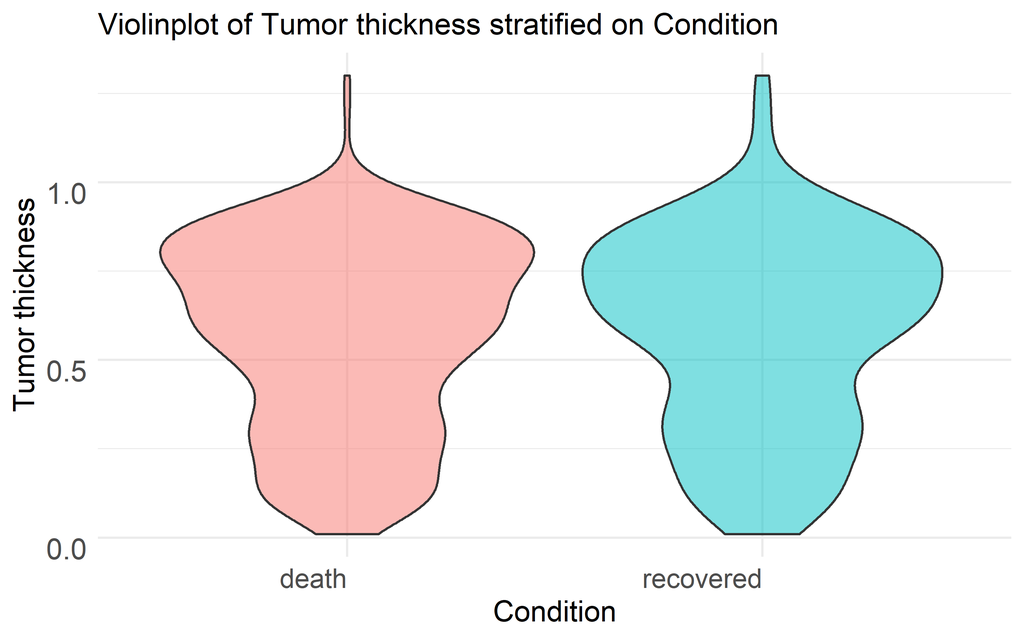

## MCA

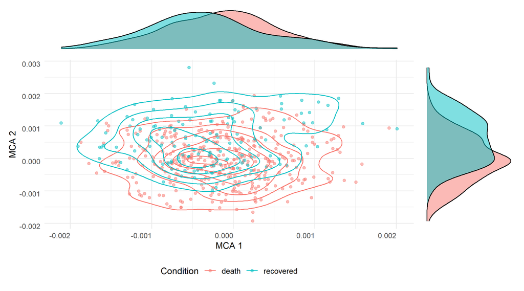

## MCA rotation

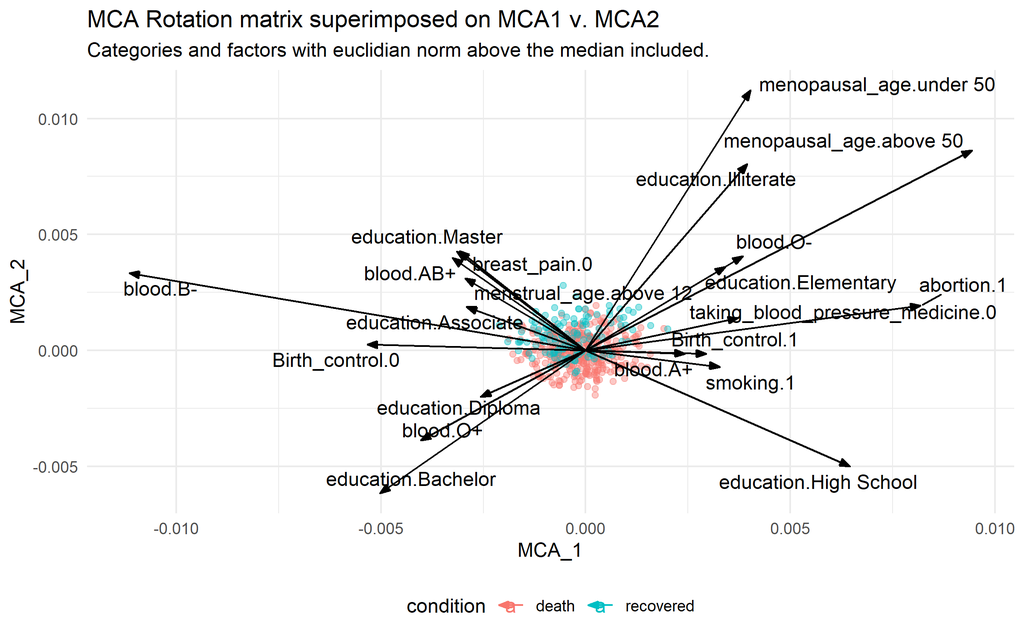

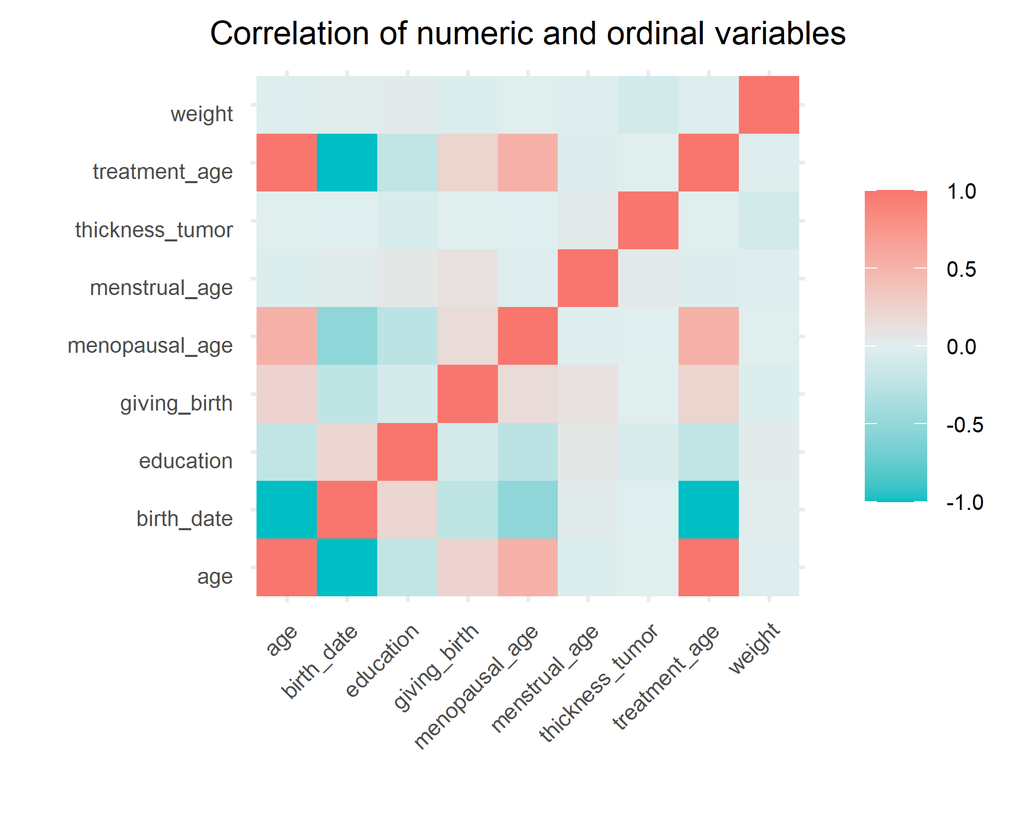

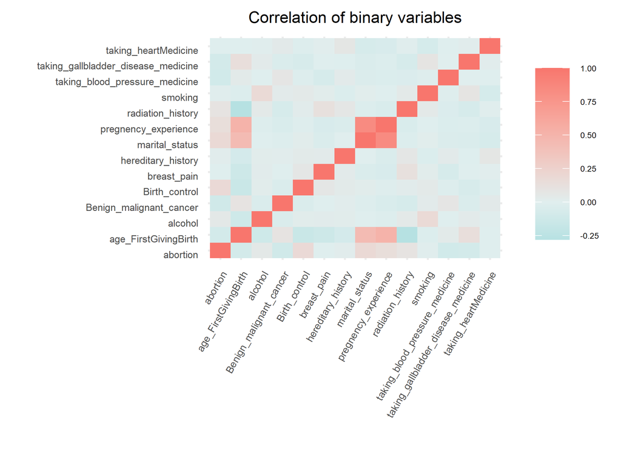

## Model

## Predicting Condition

**Reduced Model**

- Education
- Age
- Weight
- Tumor type
- Hereditary history
- Giving birth
- Age FirstGivingBirth
- Radiation history
- Menstrual age
- Abortion
- Breast pain

| Model | Sensitivity | Specificity | Balanced accuracy |
| --- | --- | --- | --- |
| Max_pred | 88% | 42% | 65% |
| Red_pred | 90% | 48% | 69% |
| baseline | 100% | 0% | 50% |

Note:  
Positive class = Death

## Shiny app

## [Shiny App](https://bernadettekc.shinyapps.io/breast_cancer_survivalcalculator)

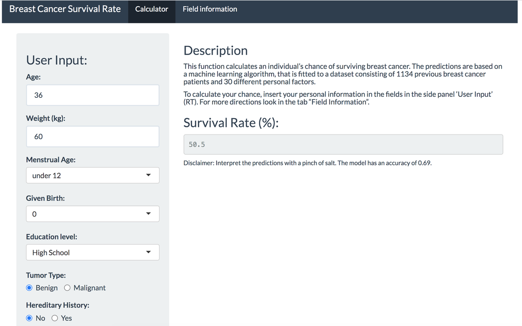

## Discussion & Conclusion

## Discussion

- Greedy cleaning approach
- Disagreement between MCA and reduced model
- A general set of rules for valid entries

## Bibliography

- 2020 Cancer incidence and mortality in EU-27 countries [EU Science Hub](https://ec.europa.eu/jrc/en/news/2020-cancer-incidence-and-mortality-eu-27-countries)
- WHO Guide to cancer early diagnosis [World Health Organization. Cancer](https://www.who.int/cancer/publications/cancer_early_diagnosis/en/)
- Breast Cancer Dataset [Kaggle](https://www.kaggle.com/homayoonkhadivi/breast-cancer-datasets)
- Breast cancer incidence (invasive) statistics (10 March 2020). Cancer Research UK
- Height Percentile Calculator for Men and Women in the United States [DQYDJ](https://dqydj.com/height-percentile-calculator-for-men-and-women)
- Weight Gain After Breast Cancer Diagnosis May Be a Bigger Issue Than Thought in Australia (13 March 2020) [Breastcancer.org](https://www.breastcancer.org/research-news/gaining-weight-after-dx-big-problem-in-australia#:~:text=The%20survey%20found%20that%20nearly,diagnosed%20was%20about%20157%20pounds)
- Github Repository [Group 9 Final Project](https://github.com/rforbiodatascience21/2021_group09_final_project)

## MCA

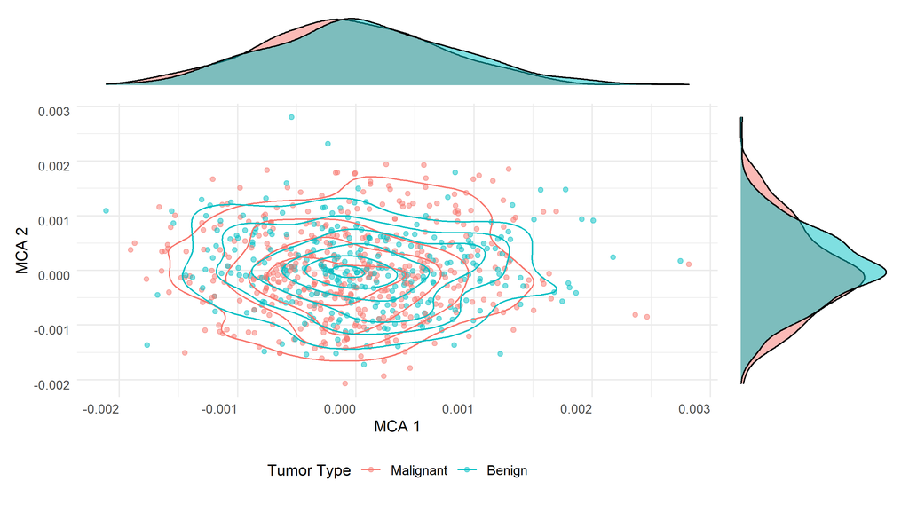

## Predicting tumortype

**Reduced Model**

- Age (norm)
- Weight (norm)
- Hereditary history
- Smoking
- Radiation therapy
- Menstrual age
- Pregnancy experience
- Abortion
- Breast pain

| model | sensitivity | specificity | balanced_accuracy |
| --- | --- | --- | --- |
| Max_pred | 69% | 28% | 48% |
| Red_pred | 81% | 24% | 53% |
| baseline | 100% | 0% | 50% |

Note:  
Positive class = Malignant